# Theory-driven meta-analysis TRACE

#### robustness of effect

```r
mod.preclinical.bias <- rma.uni(yi, vi,
                                # random = list(~1 | new.idPTSD , ~1 | PMID),
                                mods = ~valence:phase-1,
                                method = "REML",
                                slab = preclinical$reference,
                                data = preclinical)
```

```r
# funnel(mod.preclinical.bias) # same shape as above
```

##### Egger’s regression

```r
regtest(mod.preclinical.bias, ret.fit = TRUE) #Egger's regression random effects (mixed not available)
```

```
##
## Regression Test for Funnel Plot Asymmetry
##
## model:     mixed-effects meta-regression model
## predictor: standard error
##
## Mixed-Effects Model (k = 1089; tau^2 estimator: REML)
##
## tau^2 (estimated amount of residual heterogeneity):     1.6930 (SE = 0.0881)
## tau (square root of estimated tau^2 value):             1.3012
## I^2 (residual heterogeneity / unaccounted variability): 87.87%
## H^2 (unaccounted variability / sampling variability):   8.24
##
## Test for Residual Heterogeneity:
## QE(df = 1081) = 5762.4624, p-val < .0001
##
## Test of Moderators (coefficients 1:8):
## QM(df = 8) = 1023.1699, p-val < .0001
##
## Model Results:
##
##                  estimate      se     zval    pval    ci.lb    ci.ub
## valenceF:phaseE   -0.9416  0.1345  -6.9992  <.0001  -1.2053  -0.6779  ***
## valenceT:phaseE   -1.4740  0.2114  -6.9725  <.0001  -1.8884  -1.0597  ***
## valenceF:phaseL    0.4790  0.1812   2.6441  0.0082   0.1239   0.8340   **
## valenceN:phaseL   -1.1640  0.1533  -7.5922  <.0001  -1.4645  -0.8635  ***
## valenceF:phaseM    1.2359  0.1537   8.0384  <.0001   0.9345   1.5372  ***
## valenceN:phaseM   -1.3116  0.1735  -7.5595  <.0001  -1.6517  -0.9716  ***
## valenceT:phaseM    2.0467  0.1390  14.7285  <.0001   1.7743   2.3190  ***
## sei               -0.2384  0.1798  -1.3262  0.1848  -0.5908   0.1140
##
## ---
## Signif. codes:  0 '***' 0.001 '**' 0.01 '*' 0.05 '.' 0.1 ' ' 1
##
## test for funnel plot asymmetry: z = -1.3262, p = 0.1848
```

##### file drawer analysis (fail and safe)

file drawer analysis is performed within valence x phase subgroups

```r
fsn.table.preclinical <- data.frame(matrix(data = NA, nrow = 7, ncol = 4)) #V new

names(fsn.table.preclinical)<-c("valence", "phase", "Fail-save N", "Pvalue")

fsn(yi = yi, vi = vi,
    data = preclinical,
    subset = (preclinical$valence == "F" & preclinical$phase == "E"),
    type = "Rosenthal") ->fsnFE.preclinical
fsnFE.preclinical
```

```
##
## Fail-safe N Calculation Using the Rosenthal Approach
##
## Observed Significance Level: <.0001
## Target Significance Level:   0.05
##
## Fail-safe N: 84555
```

```r
fsn.table.preclinical[1,] <- c("F", "E", fsnFE.preclinical$fsnum, fsnFE.preclinical$pval)
```

```r
fsn(yi = yi, vi = vi,
    data = preclinical,
    subset = (preclinical$valence == "T" & preclinical$phase == "E"),
    type = "Rosenthal")->fsnTE.preclinical
fsnTE.preclinical
```

```
##
## Fail-safe N Calculation Using the Rosenthal Approach
##
## Observed Significance Level: <.0001
## Target Significance Level:   0.05
##
## Fail-safe N: 10702
```

```r
fsn.table.preclinical[2,] <- c("T", "E", fsnTE.preclinical$fsnum, fsnTE.preclinical$pval)
```

```r
fsn(yi = yi, vi = vi,
    data = preclinical,
    subset = (preclinical$valence == "F" & preclinical$phase == "L"),
    type = "Rosenthal") ->fsnFL.preclinical
fsnFL.preclinical
```

```
##
## Fail-safe N Calculation Using the Rosenthal Approach
##
## Observed Significance Level: <.0001
## Target Significance Level:   0.05
##
## Fail-safe N: 867
```

```r
fsn.table.preclinical[3,] <- c("F", "L", fsnFL.preclinical$fsnum, fsnFL.preclinical$pval)
```

```r
fsn(yi = yi, vi = vi,
    data = preclinical,
    subset = (preclinical$valence == "N" & preclinical$phase == "L"),
    type = "Rosenthal")->fsnNL.preclinical
fsnNL.preclinical
```

```
##
## Fail-safe N Calculation Using the Rosenthal Approach
##
## Observed Significance Level: <.0001
## Target Significance Level:   0.05
##
## Fail-safe N: 35308
```

```r
fsn.table.preclinical[4,] <- c("N", "L", fsnNL.preclinical$fsnum, fsnNL.preclinical$pval)
```

```r
fsn(yi = yi, vi = vi,
    data = preclinical,
    subset = (preclinical$valence == "F" & preclinical$phase == "M"),
    type = "Rosenthal")->fsnFM.preclinical
fsnFM.preclinical
```

```
##
## Fail-safe N Calculation Using the Rosenthal Approach
##
## Observed Significance Level: <.0001
## Target Significance Level:   0.05
##
## Fail-safe N: 27443
```

```r
fsn.table.preclinical[5,] <- c("F", "M", fsnFM.preclinical$fsnum, fsnFM.preclinical$pval)
```

```r
fsn(yi = yi, vi = vi,
    data = preclinical,
    subset = (preclinical$valence == "N" & preclinical$phase == "M"),
    type = "Rosenthal")->fsnNM.preclinical
fsnNM.preclinical
```

```
##
## Fail-safe N Calculation Using the Rosenthal Approach
##
## Observed Significance Level: <.0001
## Target Significance Level:   0.05
##
## Fail-safe N: 21941
```

```r
fsn.table.preclinical[6,] <- c("N", "M", fsnNM.preclinical$fsnum, fsnNM.preclinical$pval)
```

```r
fsn(yi = yi, vi = vi,
    data = preclinical,
    subset = (preclinical$valence == "T" & preclinical$phase == "M"),
    type = "Rosenthal")->fsnTM.preclinical
fsnTM.preclinical
```

```
##
## Fail-safe N Calculation Using the Rosenthal Approach
##
## Observed Significance Level: <.0001
## Target Significance Level:   0.05
##
## Fail-safe N: 265760
```

```r
fsn.table.preclinical[7,] <- c("T", "M", fsnTM.preclinical$fsnum, fsnTM.preclinical$pval)
```

###### view and save complete table

```r
fsn.table.preclinical$Pvalue <- round(as.numeric(fsn.table.preclinical$Pvalue),3)
fsn.table.preclinical$Pvalue<- ifelse(fsn.table.preclinical$Pvalue == 0, "<.001",fsn.table.preclinical$Pvalue)

fsn.table.preclinical
```

```
##   valence phase Fail-save N Pvalue
## 1       F     E       84555  <.001
## 2       T     E       10702  <.001
## 3       F     L         867  <.001
## 4       N     L       35308  <.001
## 5       F     M       27443  <.001
## 6       N     M       21941  <.001
## 7       T     M      265760  <.001
```

```r
write.csv2(fsn.table.preclinical, "results/phase_valence_PTSD_preclinical.FSN.csv")
```

##### trim and fill

only available for model without moderators, since moderation is present (with opposit effects).. not valid test for robustness of the effects?

### Sensitivity analysis

#### study quality

```r
mod.preclinical.QA <- rma.mv(yi, vi,
                             random = list(~1 | new.idPTSD , ~1 | PMID),
                             mods = ~RoB_score,#*valence:phase-1,  # valeria doet ook alleen 'blinding and randomized variable as moderator in model"
                             method = "REML",
                             slab = preclinical$reference,
                             data = preclinical)
summary(mod.preclinical.QA)
```

```
##
## Multivariate Meta-Analysis Model (k = 1089; method: REML)
##
##     logLik    Deviance         AIC         BIC        AICc
## -3064.0317   6128.0634   6136.0634   6156.0282   6136.1004
##
## Variance Components:
##
##             estim    sqrt  nlvls  fixed      factor
## sigma^2.1  0.2305  0.4801    309     no  new.idPTSD
## sigma^2.2  3.9080  1.9769    182     no        PMID
##
## Test for Residual Heterogeneity:
## QE(df = 1087) = 9448.7082, p-val < .0001
##
## Test of Moderators (coefficient 2):
## QM(df = 1) = 0.0889, p-val = 0.7656
##
## Model Results:
##
##            estimate      se     zval    pval    ci.lb   ci.ub
## intrcpt      0.6381  0.8924   0.7150  0.4746  -1.1110  2.3871
## RoB_score   -0.0826  0.2771  -0.2981  0.7656  -0.6258  0.4605
##
## ---
## Signif. codes:  0 '***' 0.001 '**' 0.01 '*' 0.05 '.' 0.1 ' ' 1
```

#### Influential cases

phase x valence meta-regression without cases that were identified as influential & outlier -> for sensitivity analysis

```r
preclinical.inf<-influentials_valence_phase(preclinical)
```

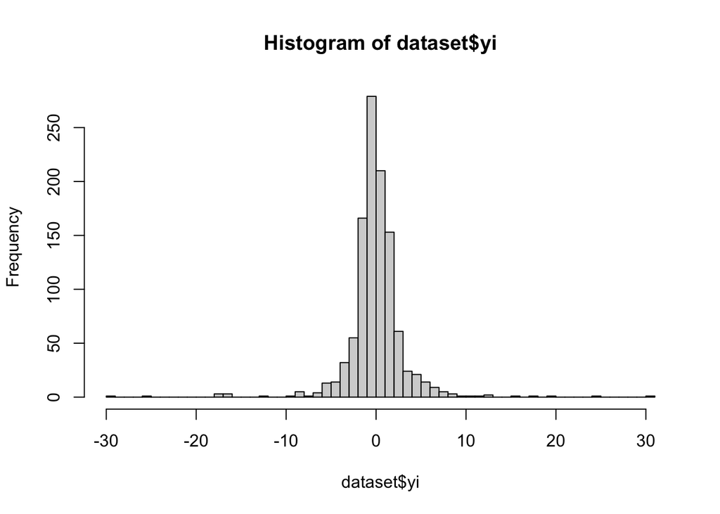

```r
saveRDS(preclinical.inf, "processed_data/influentials.preclinical.rds")
```

```r
 readRDS("processed_data/influentials.preclinical.rds")->preclinical.inf
```

potential outliers and influential cases

```r
preclinical.inf[which(preclinical.inf$outInf == 1),] %>% nrow()
```

```
## [1] 15
```

studies with potential outliers and influential cases

```r
preclinical.inf[which(preclinical.inf$outInf == 1),] %>% distinct(PMID) %>% nrow()
```

```
## [1] 8
```

```r
# preclinical.inf %>% filter(outInf == 1 & potOut==1) %>% nrow() # 11 comparisons
# preclinical.inf %>% filter(outInf == 1 & potOut==1) %>% distinct(PMID) %>% nrow() # 4 papers

# # potential outliers
# preclinical.inf[which(preclinical.inf$potOut == 1),] %>% nrow() # 28 comparisons
# preclinical.inf[which(preclinical.inf$potOut == 1),] %>% distinct(PMID) %>% nrow() # 14 papers
# preclinical.inf %>% filter(potOut!=1) #->data.sens
```

remove potential outliers and influential cases (Viechtbauer & Cheung)

```r
# preclinical.inf %>%
#  filter(outInf != 1) %>%
# droplevels() -> preclinical.noinf # n=4 papers (11 comparison) excluded animal

preclinical.inf %>%
  filter(outInf != 1) %>%  # potential outliers AND influential
  # filter(potOut!=1) %>%
  droplevels() -> preclinical.noinfnoout
```

Model without potential outliers and influential cases

```r
mod.preclinical.noinf <- rma.mv(yi, vi,
                                random = list(~1 | new.idPTSD , ~1 | PMID),
                                mods = ~valence:phase-1,
                                method = "REML",
                                slab = preclinical.noinfnoout$reference,  # from old codes milou (change for author/year)
                                data = preclinical.noinfnoout) # Similar effects with dat2 (trauma learning excluded)
summary(mod.preclinical.noinf)
```

```
##
## Multivariate Meta-Analysis Model (k = 1074; method: REML)
##
##     logLik    Deviance         AIC         BIC        AICc
## -2158.6335   4317.2670   4335.2670   4380.0204   4335.4373
##
## Variance Components:
##
##             estim    sqrt  nlvls  fixed      factor
## sigma^2.1  0.2148  0.4634    305     no  new.idPTSD
## sigma^2.2  0.9859  0.9929    181     no        PMID
##
## Test for Residual Heterogeneity:
## QE(df = 1067) = 4990.7307, p-val < .0001
##
## Test of Moderators (coefficients 1:7):
## QM(df = 7) = 1515.3174, p-val < .0001
##
## Model Results:
##
##                  estimate      se      zval    pval    ci.lb    ci.ub
## valenceF:phaseE   -0.7434  0.1188   -6.2605  <.0001  -0.9762  -0.5107  ***
## valenceT:phaseE   -2.1362  0.2135  -10.0045  <.0001  -2.5547  -1.7177  ***
## valenceF:phaseL    0.4284  0.1285    3.3327  0.0009   0.1765   0.6804  ***
## valenceN:phaseL   -1.2508  0.1384   -9.0354  <.0001  -1.5221  -0.9795  ***
## valenceF:phaseM    0.8157  0.1184    6.8882  <.0001   0.5836   1.0478  ***
## valenceN:phaseM   -1.2882  0.1343   -9.5887  <.0001  -1.5515  -1.0249  ***
## valenceT:phaseM    1.8795  0.1191   15.7786  <.0001   1.6461   2.1130  ***
##
## ---
## Signif. codes:  0 '***' 0.001 '**' 0.01 '*' 0.05 '.' 0.1 ' ' 1
```

save

```r
# create same structure as main analysis: effectsize    se  ci.lb   ci.ub   Zvalue  Pvalue  Pvalue_bonfCorr
  cbind(rownames(mod.preclinical.noinf$b),
        round(
                 data.frame(
                 mod.preclinical.noinf$b, mod.preclinical.noinf$se,
                 mod.preclinical.noinf$ci.lb, mod.preclinical.noinf$ci.ub,
                 mod.preclinical.noinf$zval, mod.preclinical.noinf$pval,row.names = NULL),
                 3)
  ) ->sens.infout.preclinical.results

colnames(sens.infout.preclinical.results)<-c("test","effectsize",   "se",   "ci.lb",    "ci.ub",    "Zvalue",   "Pvalue")

# correct pvalue 0
sens.infout.preclinical.results %>% mutate(Pvalue= ifelse(Pvalue == 0, "<.001", Pvalue))->sens.infout.preclinical.results2

write.csv2(sens.infout.preclinical.results2,"results/sens.preclinical.infout.csv")
```

#### comparision types

##### E non-trauma exposed vs PTSD

[A= non-exposed vs trauma-exposed PTSD (human); E=non-exposed vs trauma-exposed PTSD (animal)

```r
data %>%
  filter(subject.cat =="Animal") %>%
  filter(comparison =="E") %>%
  droplevels() ->preclinical.HC.PTSD

preclinical.HC.PTSD %>% group_by(phase, valence) %>%
  summarize(papers=length(unique(PMID)), comparisons=length(each)) %>% data.frame()
```

```
##   phase valence papers comparisons
## 1     E       F      1          12
## 2     L       F      1           2
## 3     M       F      2           9
## 4     M       T      9          24
```

```r
rma.mv(yi, vi,
       random = list(~1 | new.idPTSD , ~1 | PMID),
       mods = ~valence:phase-1,
       method = "REML",
       slab = preclinical.HC.PTSD$reference,
       data = preclinical.HC.PTSD) -> mod.E
mod.E%>% summary()
```

```
##
## Multivariate Meta-Analysis Model (k = 47; method: REML)
##
##   logLik  Deviance       AIC       BIC      AICc
## -45.9500   91.9000  103.9000  114.4672  106.2334
##
## Variance Components:
##
##             estim    sqrt  nlvls  fixed      factor
## sigma^2.1  0.0486  0.2203     16     no  new.idPTSD
## sigma^2.2  1.2524  1.1191     11     no        PMID
##
## Test for Residual Heterogeneity:
## QE(df = 43) = 119.7608, p-val < .0001
##
## Test of Moderators (coefficients 1:4):
## QM(df = 4) = 84.9384, p-val < .0001
##
## Model Results:
##
##                  estimate      se     zval    pval    ci.lb   ci.ub
## valenceF:phaseE   -1.3228  0.8206  -1.6119  0.1070  -2.9312  0.2857
## valenceF:phaseL    0.4724  0.8895   0.5311  0.5954  -1.2710  2.2157
## valenceF:phaseM    0.4515  0.8113   0.5565  0.5779  -1.1386  2.0416
## valenceT:phaseM    1.8348  0.4178   4.3911  <.0001   1.0158  2.6537  ***
##
## ---
## Signif. codes:  0 '***' 0.001 '**' 0.01 '*' 0.05 '.' 0.1 ' ' 1
```

save

```r
# create same structure as main analysis: effectsize    se  ci.lb   ci.ub   Zvalue  Pvalue  Pvalue_bonfCorr
  cbind(rownames(mod.E$b),
        round(
                 data.frame(
                 mod.E$b, mod.E$se,
                 mod.E$ci.lb, mod.E$ci.ub,
                 mod.E$zval, mod.E$pval,row.names = NULL),
                 3)
  ) ->mod.E.results

colnames(mod.E.results)<-c("test","effectsize", "se",   "ci.lb",    "ci.ub",    "Zvalue",   "Pvalue")

# correct pvalue 0
mod.E.results %>% mutate(Pvalue= ifelse(Pvalue == 0, "<.001", Pvalue))->mod.E.results2

write.csv2(mod.E.results2,"results/sens.mod.E.csv")
```

##### D non-trauma exposed vs trauma-exposed HC

B=non-exposed vs trauma exposed no PTSD (human); D=non-exposed vs trauma-exposed (no PTSD checked) (animal)

```r
# Preclinical data
data %>%
  filter(subject.cat =="Animal") %>%
  filter(comparison =="D") %>%
  droplevels() ->preclinical.HC.TC

preclinical.HC.TC %>% group_by(phase, valence) %>%
  summarize(papers=length(unique(PMID)), comparisons=length(each)) %>% data.frame()
```

```
##   phase valence papers comparisons
## 1     E       F     44         242
## 2     E       T      7          68
## 3     L       F     30          79
## 4     L       N     27         120
## 5     M       F     65         126
## 6     M       N     45          94
## 7     M       T     67         234
```

```r
rma.mv(yi, vi,
       random = list(~1 | new.idPTSD , ~1 | PMID),
       mods = ~valence:phase-1,
       method = "REML",
       slab = preclinical.HC.TC$reference,
       data = preclinical.HC.TC) -> mod.D
summary(mod.D)
```

```
##
## Multivariate Meta-Analysis Model (k = 963; method: REML)
##
##     logLik    Deviance         AIC         BIC        AICc
## -2186.4025   4372.8050   4390.8050   4434.5699   4390.9953
##
## Variance Components:
##
##             estim    sqrt  nlvls  fixed      factor
## sigma^2.1  0.2710  0.5206    293     no  new.idPTSD
## sigma^2.2  1.6683  1.2916    170     no        PMID
##
## Test for Residual Heterogeneity:
## QE(df = 956) = 5295.7045, p-val < .0001
##
## Test of Moderators (coefficients 1:7):
## QM(df = 7) = 1309.7909, p-val < .0001
##
## Model Results:
##
##                  estimate      se     zval    pval    ci.lb    ci.ub
## valenceF:phaseE   -0.7184  0.1431  -5.0192  <.0001  -0.9990  -0.4379  ***
## valenceT:phaseE   -2.3819  0.2445  -9.7419  <.0001  -2.8611  -1.9027  ***
## valenceF:phaseL    0.4423  0.1521   2.9085  0.0036   0.1442   0.7403   **
## valenceN:phaseL   -1.2524  0.1611  -7.7756  <.0001  -1.5681  -0.9367  ***
## valenceF:phaseM    0.8281  0.1425   5.8119  <.0001   0.5488   1.1074  ***
## valenceN:phaseM   -1.2980  0.1561  -8.3168  <.0001  -1.6039  -0.9921  ***
## valenceT:phaseM    1.8998  0.1484  12.8045  <.0001   1.6090   2.1906  ***
##
## ---
## Signif. codes:  0 '***' 0.001 '**' 0.01 '*' 0.05 '.' 0.1 ' ' 1
```

save

```r
# create same structure as main analysis: effectsize    se  ci.lb   ci.ub   Zvalue  Pvalue  Pvalue_bonfCorr
  cbind(rownames(mod.D$b),
        round(
                 data.frame(
                 mod.D$b, mod.D$se,
                 mod.D$ci.lb, mod.D$ci.ub,
                 mod.D$zval, mod.D$pval,row.names = NULL),
                 3)
  ) ->mod.D.results

colnames(mod.D.results)<-c("test","effectsize", "se",   "ci.lb",    "ci.ub",    "Zvalue",   "Pvalue")

# correct pvalue 0
mod.D.results %>% mutate(Pvalue= ifelse(Pvalue == 0, "<.001", Pvalue))->mod.D.results2

write.csv2(mod.D.results2,"results/sens.mod.D.csv")
```

##### F trauma exposed vs PTSD

C=trauma-exposed (noPTSD) vs trauma-exposed PTSD (human); F=trauma-exposed (no ptsd) vs trauma-exposed PTSD (animal)]

```r
# Preclinical data
data %>%
  filter(subject.cat =="Animal") %>%
  filter(comparison =="F") %>%
  droplevels() ->preclinical.TC.PTSD

preclinical.TC.PTSD %>% group_by(phase, valence) %>%
  summarize(papers=length(unique(PMID)), comparisons=length(each)) %>% data.frame()
```

```
##   phase valence papers comparisons
## 1     E       F      2          17
## 2     E       T      1           2
## 3     L       F      2           4
## 4     L       N      1          16
## 5     M       F      4           9
## 6     M       N      1           4
## 7     M       T     10          27
```

```r
rma.mv(yi, vi,
       random = list(~1 | new.idPTSD , ~1 | PMID),
       mods = ~valence:phase-1,
       method = "REML",
       slab = preclinical.TC.PTSD$reference,
       data = preclinical.TC.PTSD) -> mod.F
summary(mod.F)
```

```
##
## Multivariate Meta-Analysis Model (k = 79; method: REML)
##
##   logLik  Deviance       AIC       BIC      AICc
## -38.7162   77.4325   95.4325  115.9225   98.3357
##
## Variance Components:
##
##             estim    sqrt  nlvls  fixed      factor
## sigma^2.1  0.0157  0.1254     21     no  new.idPTSD
## sigma^2.2  0.0945  0.3073     15     no        PMID
##
## Test for Residual Heterogeneity:
## QE(df = 72) = 85.3063, p-val = 0.1353
##
## Test of Moderators (coefficients 1:7):
## QM(df = 7) = 104.6936, p-val < .0001
##
## Model Results:
##
##                  estimate      se     zval    pval    ci.lb    ci.ub
## valenceF:phaseE   -0.9153  0.2244  -4.0784  <.0001  -1.3552  -0.4754  ***
## valenceT:phaseE   -0.9585  0.4688  -2.0445  0.0409  -1.8774  -0.0396    *
## valenceF:phaseL    0.2357  0.2996   0.7866  0.4315  -0.3515   0.8228
## valenceN:phaseL   -0.1699  0.3370  -0.5043  0.6140  -0.8304   0.4905
## valenceF:phaseM    0.3546  0.2244   1.5807  0.1140  -0.0851   0.7944
## valenceN:phaseM    0.1433  0.3515   0.4076  0.6836  -0.5457   0.8323
## valenceT:phaseM    0.9601  0.1524   6.3006  <.0001   0.6614   1.2588  ***
##
## ---
## Signif. codes:  0 '***' 0.001 '**' 0.01 '*' 0.05 '.' 0.1 ' ' 1
```

save

```r
# create same structure as main analysis: effectsize    se  ci.lb   ci.ub   Zvalue  Pvalue  Pvalue_bonfCorr
  cbind(rownames(mod.F$b),
        round(
                 data.frame(
                 mod.F$b, mod.F$se,
                 mod.F$ci.lb, mod.F$ci.ub,
                 mod.F$zval, mod.F$pval,row.names = NULL),
                 3)
  ) ->mod.F.results

colnames(mod.F.results)<-c("test","effectsize", "se",   "ci.lb",    "ci.ub",    "Zvalue",   "Pvalue")

# correct pvalue 0
mod.F.results %>% mutate(Pvalue= ifelse(Pvalue == 0, "<.001", Pvalue))->mod.F.results2

write.csv2(mod.F.results2,"results/sens.mod.F.csv")
```

# Merge clinical and preclinical plots

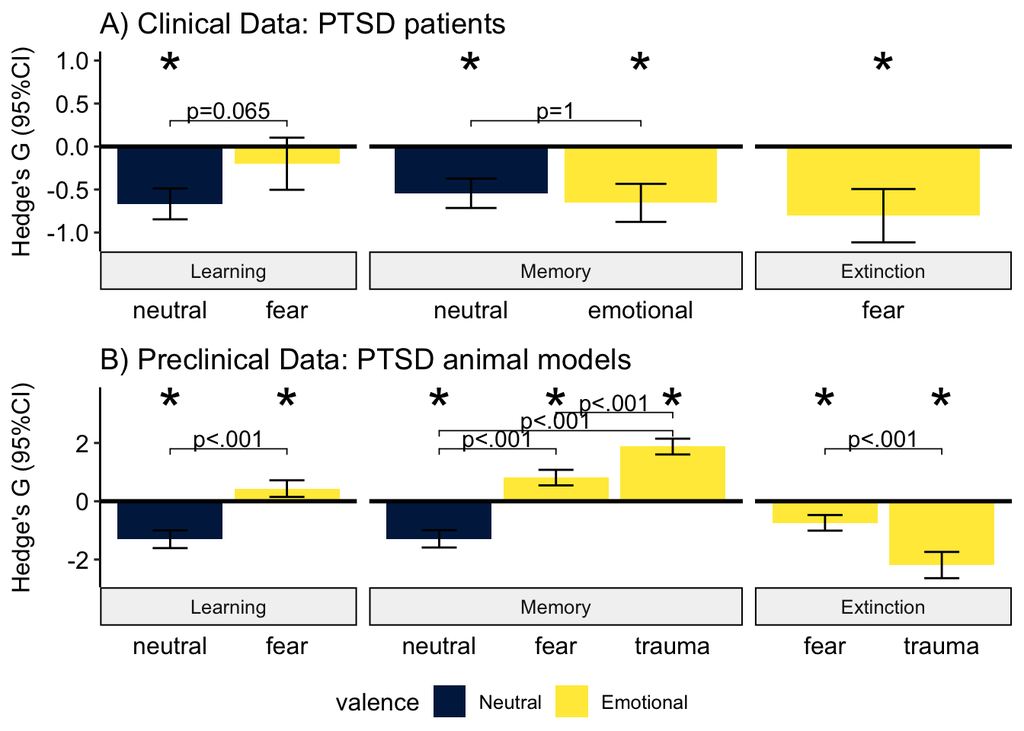

```r
# Show clincal & preclinical data in one figure.
plots<-ggarrange(
  PLOT.clinical + rremove("x.axis") + rremove("x.ticks") + rremove("xlab"),
  # + rremove("y.axis") + rremove("y.ticks")
  # ,

  PLOT.preclinical + rremove("x.axis") + rremove("x.ticks") + rremove("xlab"),
    # +rremove("y.axis") + rremove("y.ticks")
  # ,
  ncol =1, nrow=2,
  align = "v",
  legend="bottom",
  common.legend = T)

plots
```

## safe results

```r
ggsave("results/PTSD.clinical.preclinical.jpg",
       plot=plots,
       device="jpg", dpi = 300, height = 8, width = 6, limitsize = T )
#ggsave(paste0("LearningMemoryPTSD_TRACE_yshared", date(),".jpg"), device="jpg", dpi = 500, height = 4, width = 6, limitsize = T )
# ppt standard 4:3
```